# Data Integration using Unsupervised Multiple Kernel Learning

Jérôme Mariette, Céline Brouard, Rémi Flamary and Nathalie Vialaneix

19 avril, 2025

# Introduction

In this vignette, we consider a subset of the original data analyzed in the article [(Mariette & Villa-Vialaneix, 2018)](http://dx.doi.org/10.1093/bioinformatics/btx682) and illustrate the usefulness of mixKernel to 1/ perform an integrative exploratory analysis as in (Mariette & Villa-Vialaneix, 2018) and to 2/ select relevant variables for unsupervised analysis.

The data include 1% of the 35,650 prokaryotic OTUs and of the 39,246 bacterial genes that were randomly selected. **The aim is to integrate prokaryotic abundances and functional processes to environmental measure with an unsupervised method**.

Install and load the mixOmics and mixKernel packages:

```r
## required python modules: autograd, numpy, scipy, sklearn
## To properly install packages, run:
# install.packages("BiocManager")
# BiocManager::install("mixOmics")
# BiocManager::install("phyloseq")
# install.packages("mixKernel")
library(mixOmics)
library(mixKernel)
```

# Loading TARA Ocean datasets

The (previously normalized) datasets are provided as matrices with matching sample names (rownames):

```r
data(TARAoceans)
# more details with: ?TARAOceans
# we check the dimension of the data:
lapply(list("phychem" = TARAoceans$phychem, "pro.phylo" = TARAoceans$pro.phylo,
            "pro.NOGs" = TARAoceans$pro.NOGs), dim)
```

```
## $phychem
## [1] 139  22
##
## $pro.phylo
## [1] 139 356
##
## $pro.NOGs
## [1] 139 638
```

# Multiple kernel computation

## Individual kernel computation

For each input dataset, a kernel is computed using the function `compute.kernel` with the choice of linear, phylogenic or abundance kernels. A user defined function can also be provided as input(argument `kernel.func`, see `?compute.kernel`).

The results are lists with a ‘kernel’ entry that stores the kernel matrix. The resulting kernels are symmetric matrices with a size equal to the number of observations (rows) in the input datasets.

```r
phychem.kernel <- compute.kernel(TARAoceans$phychem, kernel.func = "linear")
pro.phylo.kernel <- compute.kernel(TARAoceans$pro.phylo, kernel.func = "abundance")
pro.NOGs.kernel <- compute.kernel(TARAoceans$pro.NOGs, kernel.func = "abundance")

# check dimensions
dim(pro.NOGs.kernel$kernel)
```

```
## [1] 139 139
```

A general overview of the correlation structure between datasets is obtained as described in Mariette and Villa-Vialaneix (2018) and displayed using the function `cim.kernel`:

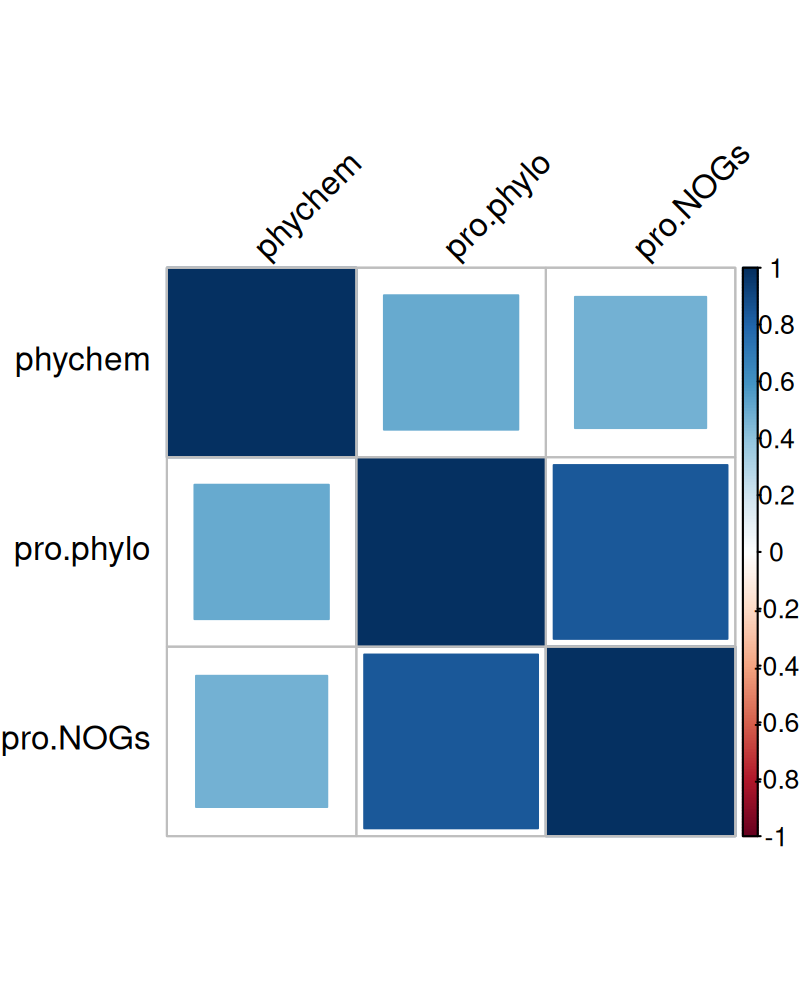

```r
cim.kernel(phychem = phychem.kernel,
           pro.phylo = pro.phylo.kernel,
           pro.NOGs = pro.NOGs.kernel,
           method = "square")
```

The figure shows that `pro.phylo` and `pro.NOGs` is the most correlated pair of kernels. This result is expected as both kernels provide a summary of prokaryotic communities.

## Combined kernel computation

The function `combine.kernels` implements 3 different methods for combining kernels: STATIS-UMKL, sparse-UMKL and full-UMKL (see more details in Mariette and Villa-Vialaneix, 2018). It returns a meta-kernel that can be used as an input for the function `kernel.pca` (kernel PCA). The three methods bring complementary information and must be chosen according to the research question.

The `STATIS-UMKL` approach gives an overview on the common information between the different datasets. The `full-UMKL` computes a kernel that minimizes the distortion between all input kernels. The `sparse-UMKL` is a sparse variant of `full-UMKL` that selects the most relevant kernels in addition to distortion minimization.

```r
meta.kernel <- combine.kernels(phychem = phychem.kernel,
                               pro.phylo = pro.phylo.kernel,
                               pro.NOGs = pro.NOGs.kernel,
                               method = "full-UMKL")
```

# Exploratory analysis: Kernel Principal Component Analysis (KPCA)

## Perform KPCA

A kernel PCA can be performed from the combined kernel with the function `` kernel.pca``. The argument ``ncomp` allows to choose how many components to extract from KPCA.

```r
kernel.pca.result <- kernel.pca(meta.kernel, ncomp = 10)
```

Sample plots using the `plotIndiv` function from `mixOmics`:

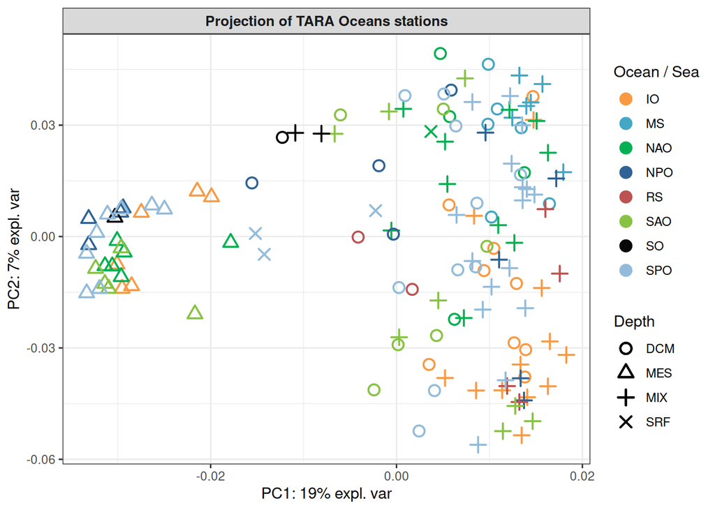

```r
all.depths <- levels(factor(TARAoceans$sample$depth))
depth.pch <- c(20, 17, 4, 3)[match(TARAoceans$sample$depth, all.depths)]
plotIndiv(kernel.pca.result,
          comp = c(1, 2),
          ind.names = FALSE,
          legend = TRUE,
          group = as.vector(TARAoceans$sample$ocean),
          col = c("#f99943", "#44a7c4", "#05b052", "#2f6395", "#bb5352",
                  "#87c242", "#07080a", "#92bbdb"),
          pch = TARAoceans$sample$depth,
          legend.title = "Ocean / Sea",
          title = "Projection of TARA Oceans stations",
          size.title = 10,
          legend.title.pch = "Depth")
```

The explained variance supported by each axis of KPCA is displayed with the `plot` function, and can help choosing the number of components in KPCA.

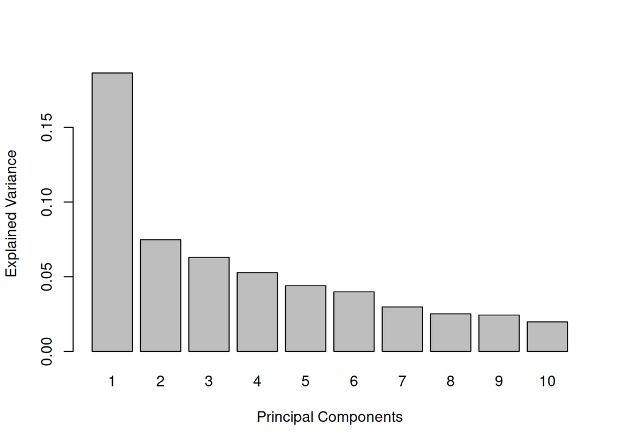

```r
plot(kernel.pca.result)
```

The first axis summarizes ~ 20% of the total variance.

## Assessing important variables

In the following example, physical variable are permuted at the variable level (kernel `phychem`), OTU abundances from `pro.phylo` kernel are permuted at the phylum level (OTU phyla are stored in the second column, named `Phylum`, of the taxonomy annotation provided in `TARAoceans` object in the entry `taxonomy`) and gene abundances from `pro.NOGs` are permuted at the GO level (GO are provided in the entry `GO` of the dataset):

```r
head(TARAoceans$taxonomy[ ,"Phylum"], 10)
```

```
##  [1] Proteobacteria Proteobacteria Proteobacteria Proteobacteria Proteobacteria
##  [6] Cyanobacteria  Proteobacteria Proteobacteria Chloroflexi    Proteobacteria
## 56 Levels: Acidobacteria Actinobacteria aquifer1 Aquificae ... WCHB1-60
```

```r
head(TARAoceans$GO, 10)
```

```
##  [1] NA  NA  "K" NA  NA  "S" "S" "S" NA  "S"
```

```r
# here we set a seed for reproducible results with this tutorial
set.seed(17051753)
kernel.pca.result <- kernel.pca.permute(kernel.pca.result, ncomp = 1,
                                        phychem = colnames(TARAoceans$phychem),
                                        pro.phylo = TARAoceans$taxonomy[, "Phylum"],
                                        pro.NOGs = TARAoceans$GO)
```

Results are displayed with the function `plotVar.kernel.pca`. The argument `ndisplay` indicates the number of variables to display for each kernel:

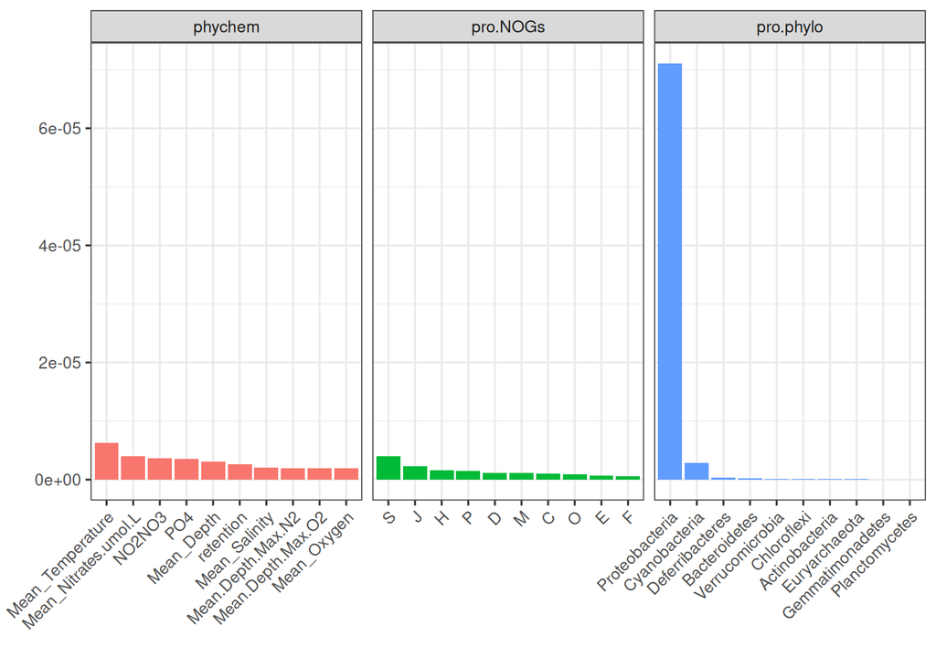

```r
plotVar.kernel.pca(kernel.pca.result, ndisplay = 10, ncol = 3)
```

`Proteobacteria` is the most important variable for the `pro.phylo` kernel.

The relative abundance of `Proteobacteria`` is then extracted in each of our 139 samples, and each sample is colored according to the value of this variable in the KPCA projection plot:

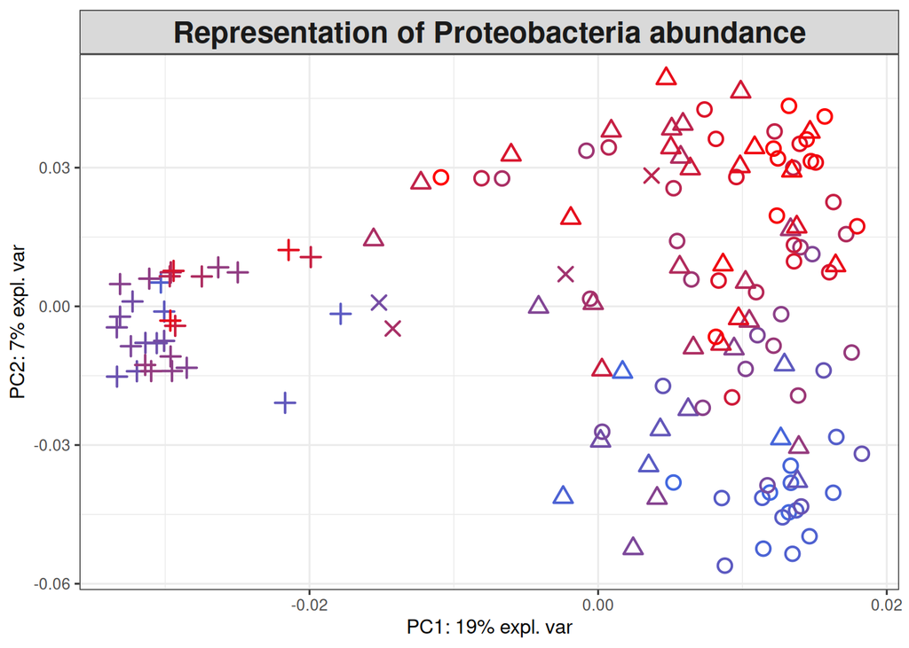

```r
selected <- which(TARAoceans$taxonomy[, "Phylum"] == "Proteobacteria")
proteobacteria.per.sample <- apply(TARAoceans$pro.phylo[, selected], 1, sum) /
  apply(TARAoceans$pro.phylo, 1, sum)
colfunc <- colorRampPalette(c("royalblue", "red"))
col.proteo <- colfunc(length(proteobacteria.per.sample))
col.proteo <- col.proteo[rank(proteobacteria.per.sample, ties = "first")]
plotIndiv(kernel.pca.result,
          comp = c(1, 2),
          ind.names = FALSE,
          legend = FALSE,
          col = col.proteo,
          pch = TARAoceans$sample$depth,
          legend.title = "Ocean / Sea",
          title = "Representation of Proteobacteria abundance",
          legend.title.pch = "Depth")
```

Similarly, the temperature is the most important variable for the `phychem` kernel. The temperature values can be displayed on the kernel PCA projection as follows:

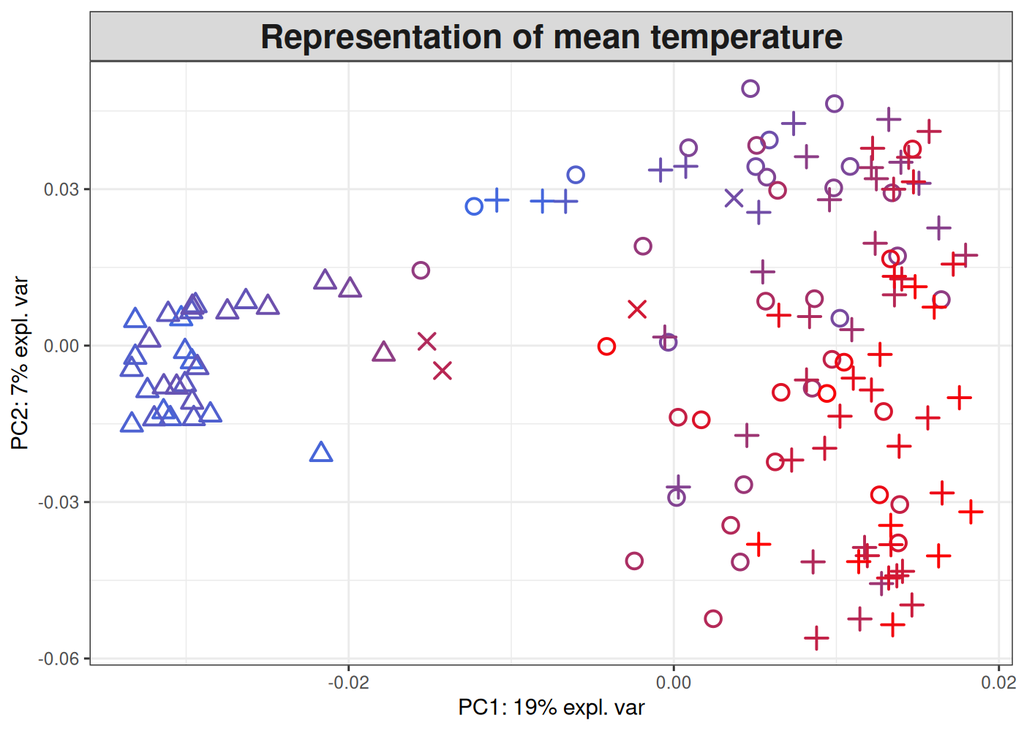

```r
col.temp <- colfunc(length(TARAoceans$phychem[, 4]))
col.temp <- col.temp[rank(TARAoceans$phychem[, 4], ties = "first")]
plotIndiv(kernel.pca.result,
          comp = c(1, 2),
          ind.names = FALSE,
          legend = FALSE,
          col = col.temp,
          pch = TARAoceans$sample$depth,
          legend.title = "Ocean / Sea",
          title = "Representation of mean temperature",
          legend.title.pch = "Depth")
```

## Selecting relevant variables

Here, we use a feature selection approach that does not rely on any assumption but explicitly takes advantage of the kernel structure in an unsupervised fashion. The idea is to preserve at best the similarity structure between samples. These examples requires the installation of the python modules `autograd`, `scipy`, `numpy`, and `sklearn`. See detailed instructions in the installation vignette or on mixKernel website : http://mixkernel.clementine.wf

```r
have_depend <- reticulate::py_module_available("autograd") &
  reticulate::py_module_available("scipy") &
  reticulate::py_module_available("numpy") &
  reticulate::py_module_available("sklearn")
```

[output not shown]

```r
if (have_depend) {
  ukfs.res <- select.features(TARAoceans$pro.phylo, kx.func = "bray", lambda = 1,
                              keepX = 5, nstep = 1)
  selected <- sort(ukfs.res, decreasing = TRUE, index.return = TRUE)$ix[1:5]
  TARAoceans$taxonomy[selected, ]
}
```

The `select.features` function allows to add a structure constraint to the variable selection. The adjacency matrix of the graph representing relations between OTUs can be obtained by computing the Pearson correlation matrix as follows:

```r
library("MASS")
library("igraph")
library("correlationtree")

pro.phylo.alist <- data.frame("names" = colnames(TARAoceans$pro.phylo),
                              t(TARAoceans$pro.phylo))
L <- mat2list(df2mat(pro.phylo.alist, 1))
corr.mat <- as.matrix(cross_cor(L, remove = TRUE))
pro.phylo.graph <- graph_from_adjacency_matrix(corr.mat,
                                               mode = "undirected",
                                               weighted = TRUE)
Lg <- laplacian_matrix(pro.phylo.graph, sparse=TRUE)
```

```r
if (have_depend) {
  load(file = file.path(system.file(package = "mixKernel"), "loaddata", "Lg.rda"))
  ukfsg.res <- select.features(TARAoceans$pro.phylo, kx.func = "bray",
                               lambda = 1, method = "graph", Lg = Lg, keepX = 5,
                               nstep = 1)

  selected <- sort(ukfsg.res, decreasing = TRUE, index.return = TRUE)$ix[1:5]
  TARAoceans$taxonomy[selected, ]
}
```

# References

1. Mariette, J. and Villa-Vialaneix, N. (2018). Unsupervised multiple kernel learning for heterogeneous data integration. *Bioinformatics*, **34**(6), 1009-1015.
2. Zhuang, J., Wang, J., Hoi, S., and Lan, X. (2011). Unsupervised multiple kernel clustering. *Journal of Machine Learning Research* (Workshop and Conference Proceedings), **20**, 129–144.
3. Lavit, C., Escoufier, Y., Sabatier, R., and Traissac, P. (1994). The act (statis method). *Computational Statistics & Data Analysis*, **18**(1), 97–119.